# Week 10 Statistical Data Mining

March 27, 2020

## Overview of the Topics

- Linear regression
- Logistic regression and activation function
- Model coefficient estimation and interpretation
- Loss function, gradient descent, optimization
- R/Python demo

## Regression Motivation

- Linear Regression: model numerical outcome
  - Simple vs. multiple regression \[ \begin{equation} \begin{aligned} f(x) &= \beta_0 + \beta_1 \cdot x_1 + ... + \beta_{i} \cdot x_i + ... + \beta_n \cdot x_n \\ &= \sum_{i=1}^n\beta_i x_i \\ &= \boldsymbol{\beta}^T\boldsymbol{x} \end{aligned} \end{equation} \]
- Logistic regression: Generalized linear regression
  - Model binary variable with two possible outcomes
  - Model multinomial categorical variables
- Key: estimation of model parameters which are coefficients in the regression model
  - Interpretation of coefficients

## Key Assumptions of Linear Regression

- Linear relationship between IVs and DVs
  - Checked by scatterplots for linear or curvlinear relationship
  - Tranformation techniques such as normalizing DV
- Homoscedasticity: similar variance of error terms across space of IVs
  - Checked by scatterplot of residuals vs. predicted values
- Multivariate normality: residues are normally distributed
- Residual/error terms should be independent: no multicollinearity
  - Tested with Variance Inflation Factor (VIF) values

## R-Squared

- Percent of variance that could be explained by the model

\[ TSS = \sum_i(y_i - \bar{y})^2 \]

\[ SSE = \sum_i(f(x_i) - y_i)^2 \]

\[ SSM = TSS - SSE \]

\[ R^2 = \frac{SSM}{TSS} \]

## Ordinary Least Square (OLS)

- Minimize sum of squared error between the data points and the regression line/model
- How to estimate regression coefficients
  - Solve the model parameters analytically (closed-form solution)
  - Use the iterative optimization algorithms (Gradient Descent, Stochastic Gradient Descent, Newton’s method, etc.)

## Ordinary Least Square (OLS)

- How to estimate the model coefficients (in specifications) that minimizes such squared difference between real value and predicted values

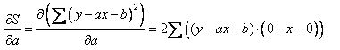

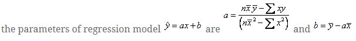

## Objective Function

- Objective function: machine learning algorithms rely on minimizing or maximizing objective functions
- Loss function: the group of objective functions that are minimized; a measure of how good a prediction model does in terms of predicting the expected outcome
  - Regression loss
  - Classification loss

## Regression Loss Function

- Mean squared error (quadratic loss, L2 loss) \[ MSE = \frac{\sum_{i = 1}^n(y_i - y_i^p)^2}{n} \]
  - Root Mean Squared Error (RMSE) \[ RMSE = \sqrt{MSE} \]
- Mean absolute error (L1 loss) \[ MAE = \frac{\sum_{i = 1}^n|y_i - y_i^p|}{n} \]

## Comparison between L1 and L2 Loss Function

- MSE/RMSE is more sensitive towards outliers than MAE
  - If outliers represent anomaly that are important, then use MSE/RMSE
  - If outliers are due to erroneous data, then use MAE
  - L2 loss function works well in most of situations and consider removing outliers first
- MAE has larger and constant gradients unlike the dynamic gradient of MSE/RMSE which adjusts accordingly to the size of error
  - MAE requires an adaptive learning rate to complement

## Other Loss Functions

- Huber loss (Smooth Mean Absolute Error)

\[ L_\delta(y, f(x)) = \begin{cases} \frac{1}{2}(y - f(x)^2)\; for |y - f(x)| \le \delta \\ \delta|y - f(x)|-\frac{1}{2}\delta^2\; otherwise \end{cases} \]

- Other considerations
  - Choice of hyperparameter \(\delta\) determines outliers: residues larger than \(\delta\) are minimized with L1; residues smaller than \(\delta\) are minimized with L2
  - Huber loss curves around the minima which decreases the gradient; and it is more robust to outliers than MSE

## Gradient Descent

- Popular optimization algorithm to find the local minimum for a differentiable function, e.g. loss function
- An iterative process of minimizing a function by following the gradient (slope) of the cost function \[ m_{n+1} = m_n - \alpha\frac{\partial}{\partial m_n}LF_{m_n} \]

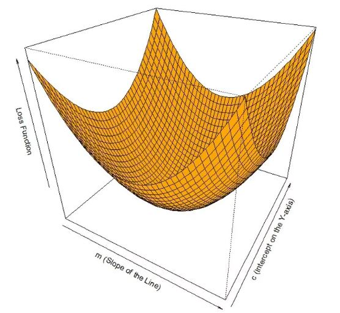

## Regression Model

- Linear regression

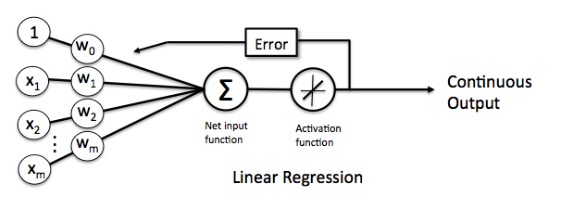

- How is a logistic regression different?
  - Activation function
  - Loss function

## Logistic/Sigmoid Function

- Logistic function

\[ f(x) = \frac{1}{1+e^{-k(x-x_0)}} \]

- Sigmoid function: a special case of logistic function or standard logistic function where \(K = 1\) and \(x_0 = 0\) \[ S(x) = \frac{1}{1+e^{-x}} \]
- Logit function: inverse of sigmoid function \[ logit(p) = log(\frac{p}{1-p}) \] \[ odd = \frac{p}{1-p} \]

## Interpretation of Logistic Regression Coefficients

\[ logit(p) = \sum_i^n{\beta_i\cdot x_i+\beta_0} \]

\[ p = \frac{1}{1+e^{-\sum_i^n\beta_i\cdot x_i+\beta_0}} \]

- How to interpret coefficient \(\beta_i\)?

\[ log(odd_1) = \beta_0 + \beta_1 \cdot x_1 + ... + \beta_{i} \cdot x_i + ... + \beta_n \cdot x_n \]

\[ log(odd_2) = \beta_0 + \beta_1 \cdot x_1 + ... + \beta_{i} \cdot (x_i + 1) + ... + \beta_n \cdot x_n \]

\[ \log(odd_2) - \log(odd_1) = \log\frac{odd_2}{odd_1} = \beta_i \]

## Sigmoid Function: S-Shape and its Properties

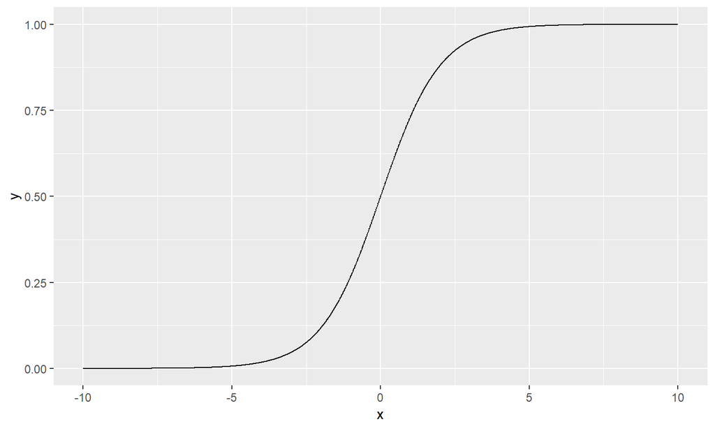

## Classification Loss Function

- Cross entropy loss function: negative log likelihood
  - \(CrossEntropyLoss(y_i, \hat{y_i}) = -(y_i\log(\hat{y_i}) + (1-y_i)\log(1-\hat{y_i}))\)
  - Increases as the predicted probability diverges from the actual label
  - Property: penalize heavily the predictions that are *confident* but *wrong*
- Gradient of cross entropy loss (or log loss)
  - \(∂E/∂p_i = – c_i / p_i + (1 – c_i)/ (1 – p_i)\)

## Regression with Regularization: Lasso vs Ridge

- Intuition: add a penalty term to loss function that is based on magnitude of coefficients as a way to reduce model complexity and overfitting, i.e. regularization
  - \(RLS = LS + \lambda\sum_{i=1}^{n}{\beta_i}^q\)
- Lasso regularization: L1 loss function (\(q = 1\))
  - Dimension reduction and feature selection
- Ridge regularization: L2 loss function (\(q = 2\))
  - Feature ranking and relative importance; but can’t zero out coefficients like Lasso
- Shrinkage parameter: \(\lambda \ge 0\)
  - \(\lambda = 0\): no regularization, just regular regression
  - As \(\lambda\) increases, the coefficients decrease

## Estimation of Coefficients of Logistic Regression

- Statistical approach: Maximum Liklihood Estimation (MLE)
  - Estimate the distribution parameters (\(\theta\)) that maximize the product of probabilities of observing all the data points
- Machine learning approach
  - Loss function: cross-entropy function
  - Optimization algorithm, e.g. stochastic gradient descent (SGD)
- Difference between two approaches

## Demo Data: Boston Housing Price

```r
library(caret)
library(mlbench)
data("BostonHousing")
str(BostonHousing)
```

```
## 'data.frame':    506 obs. of  14 variables:
##  $ crim   : num  0.00632 0.02731 0.02729 0.03237 0.06905 ...
##  $ zn     : num  18 0 0 0 0 0 12.5 12.5 12.5 12.5 ...
##  $ indus  : num  2.31 7.07 7.07 2.18 2.18 2.18 7.87 7.87 7.87 7.87 ...
##  $ chas   : Factor w/ 2 levels "0","1": 1 1 1 1 1 1 1 1 1 1 ...
##  $ nox    : num  0.538 0.469 0.469 0.458 0.458 0.458 0.524 0.524 0.524 0.524 ...
##  $ rm     : num  6.58 6.42 7.18 7 7.15 ...
##  $ age    : num  65.2 78.9 61.1 45.8 54.2 58.7 66.6 96.1 100 85.9 ...
##  $ dis    : num  4.09 4.97 4.97 6.06 6.06 ...
##  $ rad    : num  1 2 2 3 3 3 5 5 5 5 ...
##  $ tax    : num  296 242 242 222 222 222 311 311 311 311 ...
##  $ ptratio: num  15.3 17.8 17.8 18.7 18.7 18.7 15.2 15.2 15.2 15.2 ...
##  $ b      : num  397 397 393 395 397 ...
##  $ lstat  : num  4.98 9.14 4.03 2.94 5.33 ...
##  $ medv   : num  24 21.6 34.7 33.4 36.2 28.7 22.9 27.1 16.5 18.9 ...
```

## Train Linear Model

```r
model_lm <- train(medv ~ ., data = BostonHousing, method = "lm")
print(model_lm)
```

```
## Linear Regression
##
## 506 samples
##  13 predictor
##
## No pre-processing
## Resampling: Bootstrapped (25 reps)
## Summary of sample sizes: 506, 506, 506, 506, 506, 506, ...
## Resampling results:
##
##   RMSE      Rsquared   MAE
##   4.731782  0.7207107  3.378688
##
## Tuning parameter 'intercept' was held constant at a value of TRUE
```

## Model Specification

```r
model_lm$finalModel
```

```
##
## Call:
## lm(formula = .outcome ~ ., data = dat)
##
## Coefficients:
## (Intercept)         crim           zn        indus        chas1
##   3.646e+01   -1.080e-01    4.642e-02    2.056e-02    2.687e+00
##         nox           rm          age          dis          rad
##  -1.777e+01    3.810e+00    6.922e-04   -1.476e+00    3.060e-01
##         tax      ptratio            b        lstat
##  -1.233e-02   -9.527e-01    9.312e-03   -5.248e-01
```

## Examine the Linear Regression Model

```r
names(summary(model_lm))
```

```
##  [1] "call"          "terms"         "residuals"     "coefficients"
##  [5] "aliased"       "sigma"         "df"            "r.squared"
##  [9] "adj.r.squared" "fstatistic"    "cov.unscaled"
```

```r
summary(model_lm)
```

```
##
## Call:
## lm(formula = .outcome ~ ., data = dat)
##
## Residuals:
##     Min      1Q  Median      3Q     Max
## -15.595  -2.730  -0.518   1.777  26.199
##
## Coefficients:
##               Estimate Std. Error t value Pr(>|t|)
## (Intercept)  3.646e+01  5.103e+00   7.144 3.28e-12 ***
## crim        -1.080e-01  3.286e-02  -3.287 0.001087 **
## zn           4.642e-02  1.373e-02   3.382 0.000778 ***
## indus        2.056e-02  6.150e-02   0.334 0.738288
## chas1        2.687e+00  8.616e-01   3.118 0.001925 **
## nox         -1.777e+01  3.820e+00  -4.651 4.25e-06 ***
## rm           3.810e+00  4.179e-01   9.116  < 2e-16 ***
## age          6.922e-04  1.321e-02   0.052 0.958229
## dis         -1.476e+00  1.995e-01  -7.398 6.01e-13 ***
## rad          3.060e-01  6.635e-02   4.613 5.07e-06 ***
## tax         -1.233e-02  3.760e-03  -3.280 0.001112 **
## ptratio     -9.527e-01  1.308e-01  -7.283 1.31e-12 ***
## b            9.312e-03  2.686e-03   3.467 0.000573 ***
## lstat       -5.248e-01  5.072e-02 -10.347  < 2e-16 ***
## ---
## Signif. codes:  0 '***' 0.001 '**' 0.01 '*' 0.05 '.' 0.1 ' ' 1
##
## Residual standard error: 4.745 on 492 degrees of freedom
## Multiple R-squared:  0.7406, Adjusted R-squared:  0.7338
## F-statistic: 108.1 on 13 and 492 DF,  p-value: < 2.2e-16
```

## Examine the Linear Regression Model (2)

```r
coef <- summary(model_lm)$coefficients
coef <- coef[coef[, 4] < 0.05, ]
coef[order(coef[, 4]), ]
```

```
##                  Estimate  Std. Error    t value     Pr(>|t|)
## lstat        -0.524758378 0.050715278 -10.347146 7.776912e-23
## rm            3.809865207 0.417925254   9.116140 1.979441e-18
## dis          -1.475566846 0.199454735  -7.398004 6.013491e-13
## ptratio      -0.952747232 0.130826756  -7.282511 1.308835e-12
## (Intercept)  36.459488385 5.103458811   7.144074 3.283438e-12
## nox         -17.766611228 3.819743707  -4.651257 4.245644e-06
## rad           0.306049479 0.066346440   4.612900 5.070529e-06
## b             0.009311683 0.002685965   3.466793 5.728592e-04
## zn            0.046420458 0.013727462   3.381576 7.781097e-04
## crim         -0.108011358 0.032864994  -3.286517 1.086810e-03
## tax          -0.012334594 0.003760536  -3.280009 1.111637e-03
## chas1         2.686733819 0.861579756   3.118381 1.925030e-03
```

## Information of the Attributes

- MEDV - Median value of owner-occupied homes in $1000’s
- CRIM - per capita crime rate by town
- ZN - proportion of residential land zoned for lots over 25,000 sq.ft.
- INDUS - proportion of non-retail business acres per town.
- CHAS - Charles River dummy variable (1 if tract bounds river; 0 otherwise)
- NOX - nitric oxides concentration (parts per 10 million)
- RM - average number of rooms per dwelling
- AGE - proportion of owner-occupied units built prior to 1940
- DIS - weighted distances to five Boston employment centres
- RAD - index of accessibility to radial highways
- TAX - full-value property-tax rate per $10,000
- PTRATIO - pupil-teacher ratio by town
- B - 1000(Bk - 0.63)^2 where Bk is the proportion of blacks by town
- LSTAT - % lower status of the population

## Model Details

```r
summary(model_lm)
```

```
##
## Call:
## lm(formula = .outcome ~ ., data = dat)
##
## Residuals:
##     Min      1Q  Median      3Q     Max
## -15.595  -2.730  -0.518   1.777  26.199
##
## Coefficients:
##               Estimate Std. Error t value Pr(>|t|)
## (Intercept)  3.646e+01  5.103e+00   7.144 3.28e-12 ***
## crim        -1.080e-01  3.286e-02  -3.287 0.001087 **
## zn           4.642e-02  1.373e-02   3.382 0.000778 ***
## indus        2.056e-02  6.150e-02   0.334 0.738288
## chas1        2.687e+00  8.616e-01   3.118 0.001925 **
## nox         -1.777e+01  3.820e+00  -4.651 4.25e-06 ***
## rm           3.810e+00  4.179e-01   9.116  < 2e-16 ***
## age          6.922e-04  1.321e-02   0.052 0.958229
## dis         -1.476e+00  1.995e-01  -7.398 6.01e-13 ***
## rad          3.060e-01  6.635e-02   4.613 5.07e-06 ***
## tax         -1.233e-02  3.760e-03  -3.280 0.001112 **
## ptratio     -9.527e-01  1.308e-01  -7.283 1.31e-12 ***
## b            9.312e-03  2.686e-03   3.467 0.000573 ***
## lstat       -5.248e-01  5.072e-02 -10.347  < 2e-16 ***
## ---
## Signif. codes:  0 '***' 0.001 '**' 0.01 '*' 0.05 '.' 0.1 ' ' 1
##
## Residual standard error: 4.745 on 492 degrees of freedom
## Multiple R-squared:  0.7406, Adjusted R-squared:  0.7338
## F-statistic: 108.1 on 13 and 492 DF,  p-value: < 2.2e-16
```

## Model Residuals’ Plot

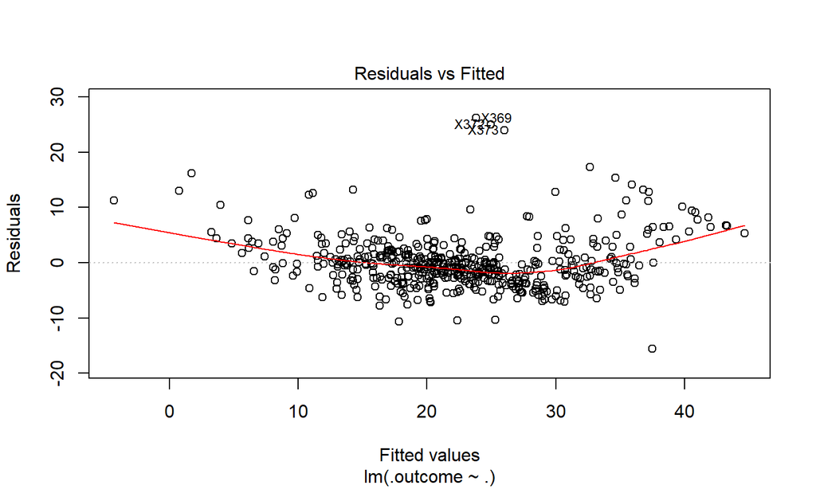

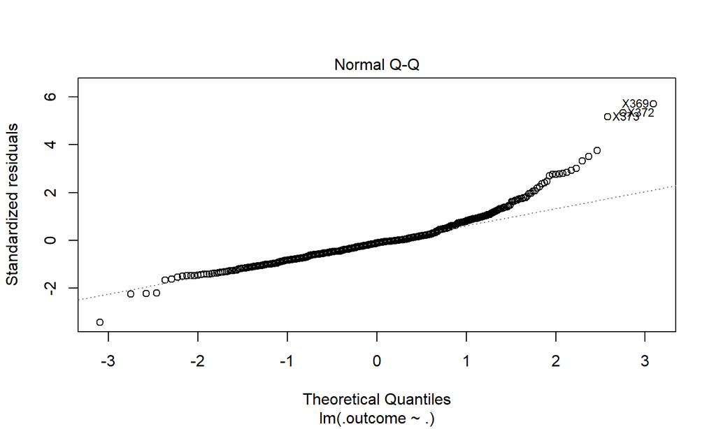

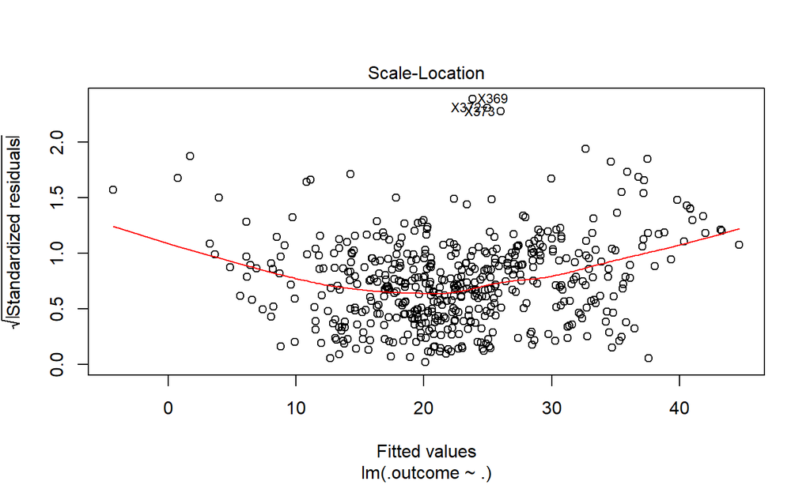

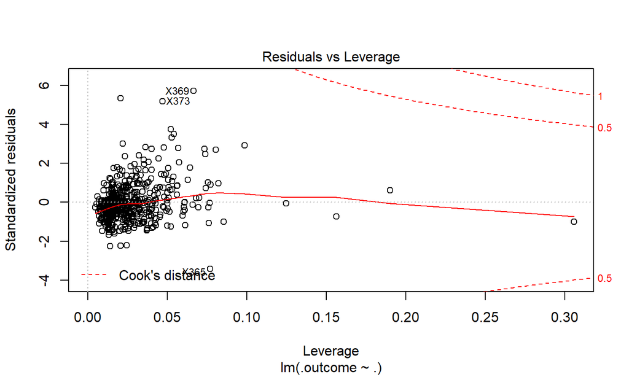

```r
plot(model_lm$finalModel)
```

## Run LM Model with Standardized Data

```r
model_lm2 <- train(medv ~ ., data = BostonHousing, method = "lm", preProcess = c("center", "scale"))
print(model_lm2)
```

```
## Linear Regression
##
## 506 samples
##  13 predictor
##
## Pre-processing: centered (13), scaled (13)
## Resampling: Bootstrapped (25 reps)
## Summary of sample sizes: 506, 506, 506, 506, 506, 506, ...
## Resampling results:
##
##   RMSE      Rsquared   MAE
##   4.913235  0.7197477  3.450471
##
## Tuning parameter 'intercept' was held constant at a value of TRUE
```

## Calculate R Square and Compare with Output (1)

```r
predict_lm <- predict(model_lm, newdata = BostonHousing, type = "raw")
real_predict <- data.frame(cbind(real = BostonHousing$medv, predict = predict_lm,
                                 square_diff = (BostonHousing$medv - predict_lm)^2))
str(real_predict)
```

```
## 'data.frame':    506 obs. of  3 variables:
##  $ real       : num  24 21.6 34.7 33.4 36.2 28.7 22.9 27.1 16.5 18.9 ...
##  $ predict    : num  30 25 30.6 28.6 27.9 ...
##  $ square_diff: num  36 11.7 17.1 23 68.2 ...
```

## Calculate R Square and Compare with Output (2)

```r
SSE <- sum(real_predict$square_diff)
TSS <- var(BostonHousing$medv) * (length(BostonHousing$medv) + 1)
R_squared <- 1 - SSE/TSS
R_squared
```

```
## [1] 0.7416658
```

```r
summary(model_lm)$r.squared
```

```
## [1] 0.7406427
```

## Logistic Regression

```r
library(arules)
BostonHousing2 <- BostonHousing
BostonHousing2$medv <- discretize(BostonHousing2$medv,
                                  method = "frequency",
                                  breaks = 2,
                                  labels = c("low", "high"))
table(BostonHousing2$medv)
```

```
##
##  low high
##  251  255
```

```r
model_glm <- train(medv ~ ., data = BostonHousing2,
                   method = "glm", family = "binomial")

print(model_glm)
```

```
## Generalized Linear Model
##
## 506 samples
##  13 predictor
##   2 classes: 'low', 'high'
##
## No pre-processing
## Resampling: Bootstrapped (25 reps)
## Summary of sample sizes: 506, 506, 506, 506, 506, 506, ...
## Resampling results:
##
##   Accuracy  Kappa
##   0.851121  0.7018285
```

## Logistic Regression Model Output

```r
summary(model_glm)
```

```
##
## Call:
## NULL
##
## Deviance Residuals:
##     Min       1Q   Median       3Q      Max
## -2.0015  -0.3574   0.0085   0.2981   3.3286
##
## Coefficients:
##              Estimate Std. Error z value Pr(>|z|)
## (Intercept) 12.065836   4.007916   3.011  0.00261 **
## crim        -0.082159   0.074950  -1.096  0.27300
## zn           0.012275   0.013525   0.908  0.36411
## indus        0.029454   0.043259   0.681  0.49594
## chas1        1.659713   0.664634   2.497  0.01252 *
## nox         -7.283784   2.733645  -2.664  0.00771 **
## rm           1.617226   0.440282   3.673  0.00024 ***
## age         -0.028603   0.010451  -2.737  0.00620 **
## dis         -0.711035   0.168061  -4.231 2.33e-05 ***
## rad          0.237470   0.060920   3.898 9.70e-05 ***
## tax         -0.008461   0.002919  -2.899  0.00374 **
## ptratio     -0.552611   0.107529  -5.139 2.76e-07 ***
## b            0.004615   0.002891   1.596  0.11041
## lstat       -0.318739   0.054587  -5.839 5.25e-09 ***
## ---
## Signif. codes:  0 '***' 0.001 '**' 0.01 '*' 0.05 '.' 0.1 ' ' 1
##
## (Dispersion parameter for binomial family taken to be 1)
##
##     Null deviance: 701.43  on 505  degrees of freedom
## Residual deviance: 273.85  on 492  degrees of freedom
## AIC: 301.85
##
## Number of Fisher Scoring iterations: 7
```

## Relative Importance of Variables by Logistic Regression

```r
varImp(model_glm)
```

```
## glm variable importance
##
##         Overall
## lstat   100.000
## ptratio  86.431
## dis      68.821
## rad      62.370
## rm       58.010
## tax      43.000
## age      39.859
## nox      38.455
## chas1    35.212
## b        17.748
## crim      8.051
## zn        4.394
## indus     0.000
```

## Import Python Libraries

```python
import pandas as pd
import numpy as np
import seaborn as sns
import matplotlib.pyplot as plt
from sklearn.datasets import load_boston
from sklearn.preprocessing import StandardScaler
from sklearn.model_selection import train_test_split
from sklearn import metrics
from sklearn.linear_model import LinearRegression, LogisticRegression
from sklearn.pipeline import make_pipeline
```

## Data Loading and Preprocessing

```python
boston = load_boston()
boston_data = pd.DataFrame(boston.data, columns = boston.feature_names)
boston_data['Price'] = boston.target
X = boston_data.drop('Price', axis=1)
y = boston_data['Price']
X_train, X_test, y_train, y_test = train_test_split(X, y, test_size=0.3, random_state=16)
boston_data.info()
```

```
## <class 'pandas.core.frame.DataFrame'>
## RangeIndex: 506 entries, 0 to 505
## Data columns (total 14 columns):
## CRIM       506 non-null float64
## ZN         506 non-null float64
## INDUS      506 non-null float64
## CHAS       506 non-null float64
## NOX        506 non-null float64
## RM         506 non-null float64
## AGE        506 non-null float64
## DIS        506 non-null float64
## RAD        506 non-null float64
## TAX        506 non-null float64
## PTRATIO    506 non-null float64
## B          506 non-null float64
## LSTAT      506 non-null float64
## Price      506 non-null float64
## dtypes: float64(14)
## memory usage: 55.5 KB
```

## Linear Regression Training and Testing

```python
lr_pipe = LinearRegression()
lr_pipe.fit(X_train, y_train)
```

```
## LinearRegression(copy_X=True, fit_intercept=True, n_jobs=None, normalize=False)
```

```python
y_pred = lr_pipe.predict(X_test)
print(f"RMSE: {round(np.sqrt(metrics.mean_squared_error(y_test, y_pred)), 3)}")
```

```
## RMSE: 4.614
```

## Visualize Regression Line

```python
plt.figure(figsize=(4, 3))
plt.scatter(y_test, y_pred)
plt.plot([0, 50], [0, 50], '--k')
plt.axis('tight')
```

```
## (-2.500483870967742, 52.51016129032258, -10.282281648953647, 52.87058484042636)
```

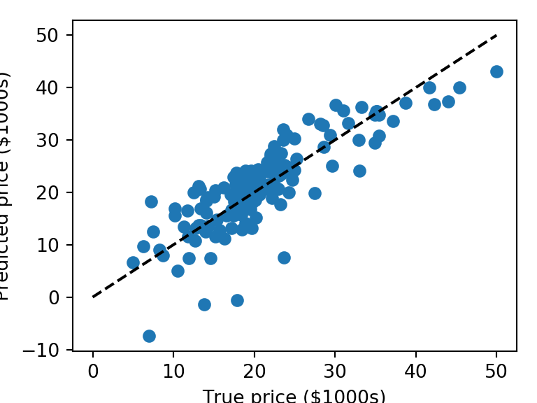

```python
plt.tight_layout()
plt.xlabel('True price ($1000s)')
plt.ylabel('Predicted price ($1000s)')
plt.show()
```

## Linear Model Coefficient Estimation

```python
for idx, col_name in enumerate(X_train.columns):
  print(f"The coefficient for {col_name} is {lr_pipe.coef_[idx]}")
```

```
## The coefficient for CRIM is -0.135721389191917
## The coefficient for ZN is 0.03531958631459615
## The coefficient for INDUS is 0.0020350011834421146
## The coefficient for CHAS is 2.425658595197517
## The coefficient for NOX is -15.996609853279406
## The coefficient for RM is 3.997523842035774
## The coefficient for AGE is 0.022861021101290676
## The coefficient for DIS is -1.3542588201878618
## The coefficient for RAD is 0.346279075866271
## The coefficient for TAX is -0.011431344325432802
## The coefficient for PTRATIO is -1.0161040881448886
## The coefficient for B is 0.010906415198789543
## The coefficient for LSTAT is -0.6351622221570083
```

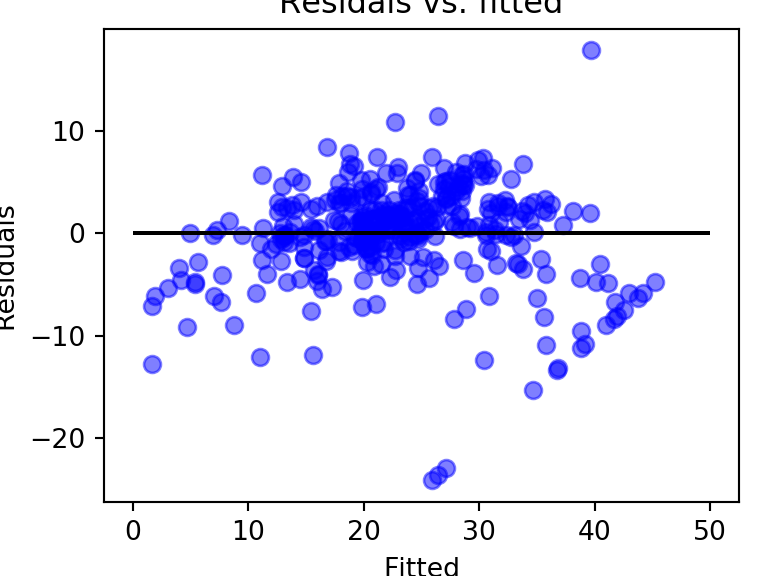

```python
plt.scatter(lr_pipe.predict(X_train), lr_pipe.predict(X_train)-y_train, c='b', s=40, alpha=0.5)
plt.hlines(y=0, xmin=0, xmax=50)
plt.xlabel("Fitted")
plt.ylabel("Residuals")
plt.title("Residals vs. fitted")
plt.show()
```

## Evaluate Linear Regression Model

```python
data_tuples = list(zip(y_test, y_pred))
real_predict = pd.DataFrame(data_tuples, columns=['Real', 'Predict'])
real_predict['squared_dif'] = (real_predict["Real"]-real_predict["Predict"])**2
real_predict.head(3)
```

```
##    Real    Predict  squared_dif
## 0  23.3  27.406211    16.860968
## 1  12.8  13.179976     0.144382
## 2   6.3   9.676904    11.403484
```

```python
SSE = sum(real_predict['squared_dif'])
TSS = np.var(y_test) * (len(y_test)+1)
real_predict.head(3)
```

```
##    Real    Predict  squared_dif
## 0  23.3  27.406211    16.860968
## 1  12.8  13.179976     0.144382
## 2   6.3   9.676904    11.403484
```

```python
Rsquared = 1 - SSE/TSS
Rsquared
```

```
## 0.6559806037964514
```

## Prepare for Logistic Regressin Dataset

```python
boston_data2 = boston_data.copy()
boston_data2['Price'] = pd.qcut(boston_data2['Price'], 2, labels=["low", "high"])
X2 = boston_data2.drop('Price', axis=1)
y2 = boston_data2['Price']
X_train2, X_test2, y_train2, y_test2 = train_test_split(X2, y2, test_size=0.3, random_state=16)
boston_data2.Price.value_counts()
```

```
## low     256
## high    250
## Name: Price, dtype: int64
```

## Logistic Regression Model Training and Testing

```python
logr_pipe = make_pipeline(StandardScaler(), LogisticRegression(solver='lbfgs'))
logr_pipe.fit(X_train2, y_train2)
```

```
## Pipeline(memory=None,
##          steps=[('standardscaler',
##                  StandardScaler(copy=True, with_mean=True, with_std=True)),
##                 ('logisticregression',
##                  LogisticRegression(C=1.0, class_weight=None, dual=False,
##                                     fit_intercept=True, intercept_scaling=1,
##                                     l1_ratio=None, max_iter=100,
##                                     multi_class='warn', n_jobs=None,
##                                     penalty='l2', random_state=None,
##                                     solver='lbfgs', tol=0.0001, verbose=0,
##                                     warm_start=False))],
##          verbose=False)
```

```python
y_pred2 = logr_pipe.predict(X_test2)
y_pred2
```

```
## array(['high', 'low', 'low', 'high', 'low', 'high', 'high', 'low', 'low',
##        'high', 'low', 'low', 'low', 'high', 'low', 'high', 'low', 'high',
##        'low', 'low', 'low', 'low', 'low', 'low', 'low', 'low', 'low',
##        'low', 'low', 'low', 'high', 'low', 'low', 'low', 'low', 'high',
##        'low', 'low', 'high', 'low', 'high', 'high', 'high', 'low', 'low',
##        'high', 'low', 'low', 'low', 'low', 'high', 'low', 'low', 'low',
##        'high', 'low', 'high', 'high', 'low', 'high', 'high', 'high',
##        'low', 'high', 'low', 'high', 'low', 'low', 'low', 'low', 'low',
##        'low', 'high', 'low', 'low', 'low', 'high', 'low', 'low', 'low',
##        'high', 'low', 'low', 'low', 'low', 'low', 'low', 'low', 'low',
##        'low', 'low', 'low', 'high', 'high', 'low', 'low', 'low', 'low',
##        'high', 'low', 'low', 'low', 'low', 'high', 'high', 'high', 'high',
##        'high', 'low', 'high', 'high', 'high', 'high', 'high', 'low',
##        'high', 'high', 'high', 'high', 'low', 'high', 'high', 'low',
##        'low', 'high', 'high', 'high', 'low', 'low', 'high', 'high',
##        'high', 'high', 'low', 'high', 'high', 'high', 'high', 'low',
##        'high', 'low', 'high', 'low', 'low', 'high', 'low', 'high', 'low',
##        'low', 'high', 'high', 'low'], dtype=object)
```